# practical_exercise_2, Methods 3, 2021, autumn semester

Emma Risgaard Olsen

29th of September 2021

# Assignment 1: Using mixed effects modelling to model hierarchical data

In this assignment we will be investigating the *politeness* dataset of Winter and Grawunder (2012) and apply basic methods of multilevel modelling.

## Dataset

The dataset has been shared on GitHub, so make sure that the csv-file is on your current path. Otherwise you can supply the full path.

# Exercises and objectives

The objectives of the exercises of this assignment are:  
1) Learning to recognize hierarchical structures within datasets and describing them  
2) Creating simple multilevel models and assessing their fitness  
3) Write up a report about the findings of the study

REMEMBER: In your report, make sure to include code that can reproduce the answers requested in the exercises below  
REMEMBER: This assignment will be part of your final portfolio

## Exercise 1 - describing the dataset and making some initial plots

1. Describe the dataset, such that someone who happened upon this dataset could understand the variables and what they contain
1. Also consider whether any of the variables in *politeness* should be encoded as factors or have the factor encoding removed. Hint: `?factor`

The dataset consists of 224 observations of 7 different variables (all listed below).

*[,1] attitude (inf = informal, pol = polite)* The attitude variable is a binary variable taking two possible values, i.e “inf” (which corresponds to “informal”) and “pol” (which corresponds to “formal”).The participants were asked to do each scenario in a formal and informal way. Each trial/scenario (n = 14) is either “informal” or “polite”, making it 50% “informal” and 50% “polite”. For analytic purposes it will be transformed into a factor variable.

```r
n <- nrow(politeness)  # Number of rows in total
(percent_attitude <- table(politeness$attitude)/n * 100) #generating percentages of gender
```

```
##
## inf pol
##  50  50
```

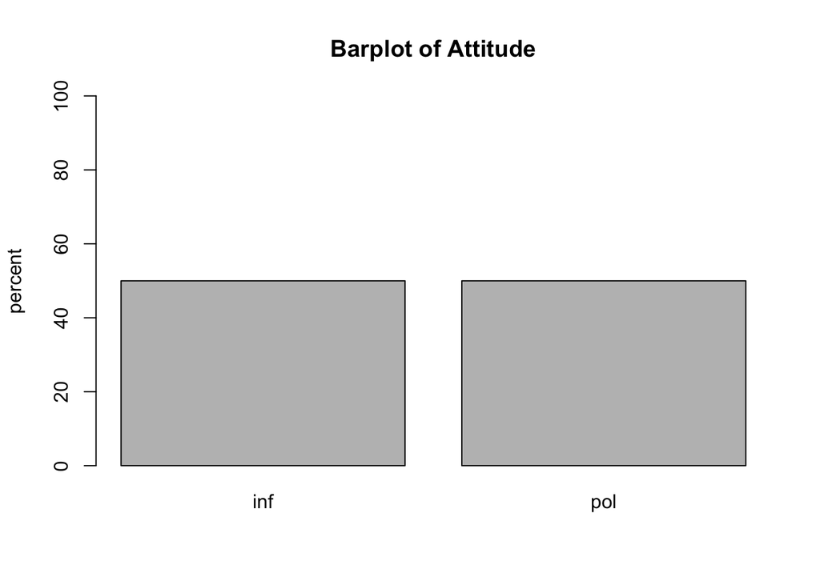

```r
politeness$attitude <- as.factor(politeness$attitude)

# Attitude variable plot
barplot(percent_attitude,ylim=c(0,100), ylab="percent",main="Barplot of Attitude")
```

*[,2] f0mn. (i.e. the base frequency, pitch)* The variable f0mn represents the frequency (i.e., pitch) of the voice in hertz. This variable is numeric and the distribution of the data is bimodal. The minimum value in the variable is 80.8 hz and the maximum value in the variable is 415.8 hz, in addition to this the mean of the variable is 197.9 hz. The f0mn variable contains some NA’s, and for analytic purposes, I replace these missing values with imputed values based on other characteristics of the record (in this context it will be replaced with a mean of f0mn for each subject).

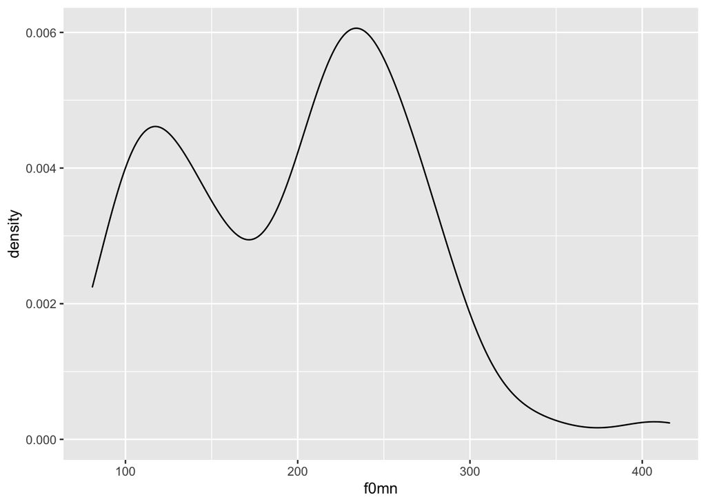

```r
# f0mn variable plot
ggplot(politeness, aes(f0mn))+geom_density()
```

```r
# replacing NA's with mean per participant
politeness <- politeness %>%
  group_by(subject) %>%
  mutate(f0mn = ifelse(is.na(f0mn), mean(f0mn, na.rm = TRUE), f0mn))
```

*[,3] gender (encoded as F or M)* The gender variable represents the gender each participant identifies with. “F” corresponds to “Female” and “M” corresponds to “Male”. 56.25% of the participants are Female and 43.75% are Male, which is also visually illustrated by a barplot. The variable is binary as it only contains either F or M, and for analytic purposes it will be transformed into a factor variable.

```r
# additional information
n <- nrow(politeness)  # Number of rows in total
(percent_gender <- table(politeness$gender)/n * 100) #generating percentages of gender
```

```
##
##     F     M
## 56.25 43.75
```

```r
ls.str(politeness) # general information
```

```
## attitude :  Factor w/ 2 levels "inf","pol": 2 1 2 1 2 1 2 1 2 1 ...
## f0mn :  num [1:224] 215 211 285 266 211 ...
## gender :  chr [1:224] "F" "F" "F" "F" "F" "F" "F" "F" "F" "F" "F" "F" "F" "F" "F" ...
## hiss_count :  int [1:224] 2 0 0 0 0 0 1 0 1 0 ...
## scenario :  int [1:224] 1 1 2 2 3 3 4 4 5 5 ...
## subject :  chr [1:224] "F1" "F1" "F1" "F1" "F1" "F1" "F1" "F1" "F1" "F1" "F1" "F1" ...
## total_duration :  num [1:224] 18.39 13.55 5.22 4.25 6.79 ...
```

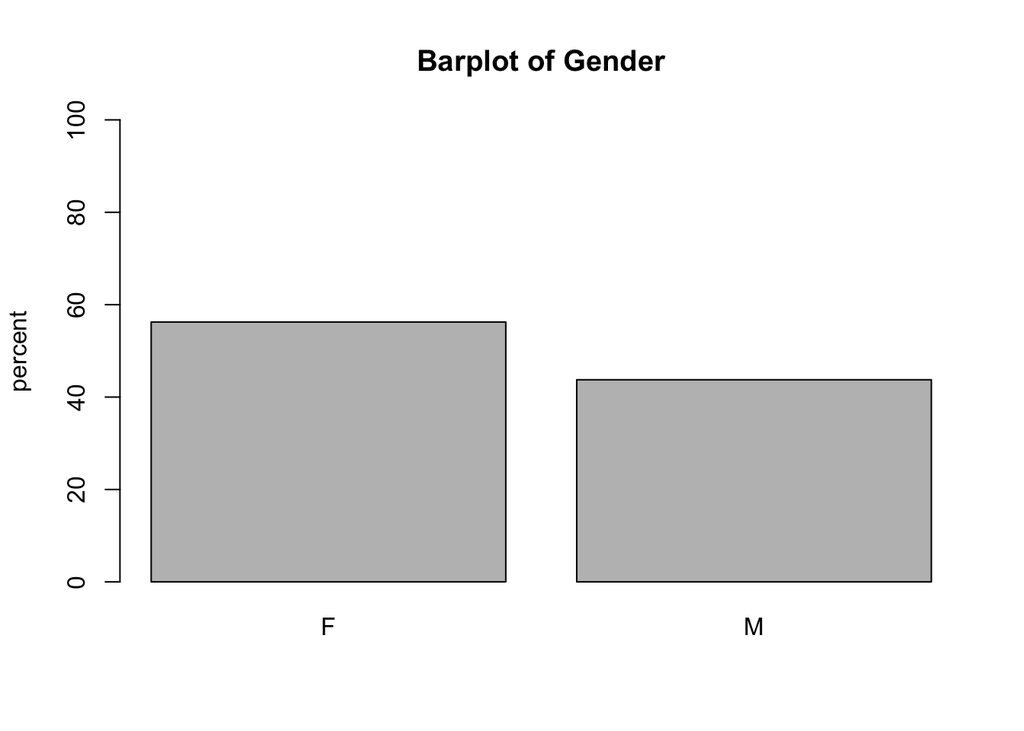

```r
politeness$gender <- as.factor(politeness$gender)

#gender variable plot
barplot(percent_gender,ylim=c(0,100), ylab="percent",main="Barplot of Gender")
```

*[,4] hiss_count. (i.e. the number of hisses made)* The hiss count variable relates to the amount of loud “hissing” breath intake. This variable is an integer variable with a minimum value hissings of 0 and a maximum hissing value of 5. The distribution of the data is positively skewed (right-skewed distribution).

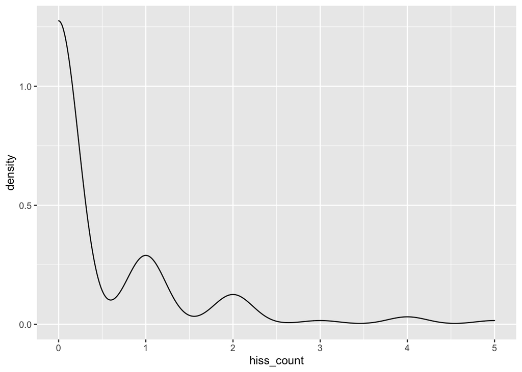

```r
#hiss count variable plot
ggplot(politeness, aes(hiss_count))+geom_density()
```

```r
#additional information:
ls.str(politeness) #general information
```

```
## attitude :  Factor w/ 2 levels "inf","pol": 2 1 2 1 2 1 2 1 2 1 ...
## f0mn :  num [1:224] 215 211 285 266 211 ...
## gender :  Factor w/ 2 levels "F","M": 1 1 1 1 1 1 1 1 1 1 ...
## hiss_count :  int [1:224] 2 0 0 0 0 0 1 0 1 0 ...
## scenario :  int [1:224] 1 1 2 2 3 3 4 4 5 5 ...
## subject :  chr [1:224] "F1" "F1" "F1" "F1" "F1" "F1" "F1" "F1" "F1" "F1" "F1" "F1" ...
## total_duration :  num [1:224] 18.39 13.55 5.22 4.25 6.79 ...
```

*[,5] scenario (i.e. an indicator of which of the 7 different scenarios the participant is in)* The scenario variable is an integer-variable and represents 7 different trials/scenarios, where each participant completes each trial/scenario twice, hence 14 rows per participant. Each participants completes these 7 different trials twice as each scenario is either “informal” or “polite”. For analytic purposes it will be transformed into a factor variable.

```r
politeness$scenario <- as.factor(politeness$scenario)
```

*[,6] subject (i.e. the participant)* The subject variable represents each participant’s individual ID, which makes it easier for us to distinguish between the participants and account for possible individual differences. This variable is a character string containing 16 different subject ID’s, each subject ID has 14 rows

```r
#additional information about subject variable
ls.str(politeness) #general information
```

```
## attitude :  Factor w/ 2 levels "inf","pol": 2 1 2 1 2 1 2 1 2 1 ...
## f0mn :  num [1:224] 215 211 285 266 211 ...
## gender :  Factor w/ 2 levels "F","M": 1 1 1 1 1 1 1 1 1 1 ...
## hiss_count :  int [1:224] 2 0 0 0 0 0 1 0 1 0 ...
## scenario :  Factor w/ 7 levels "1","2","3","4",..: 1 1 2 2 3 3 4 4 5 5 ...
## subject :  chr [1:224] "F1" "F1" "F1" "F1" "F1" "F1" "F1" "F1" "F1" "F1" "F1" "F1" ...
## total_duration :  num [1:224] 18.39 13.55 5.22 4.25 6.79 ...
```

```r
length(unique(politeness$subject)) #amount of different participants
```

```
## [1] 16
```

```r
politeness$subject <- as.factor(politeness$subject)
```

*[,7] total_duration (i.e. the duration of a given scenario)* The total duration variable is a numeric variable representing duration of each response (for how much time the participants were talking). The distribution of the variable is positively skewed (right-skewed distribution).The minimum value in the variable is 0.988 and the maximum value in the variable is 101.375, in addition to this the mean of the variable is 24.176.

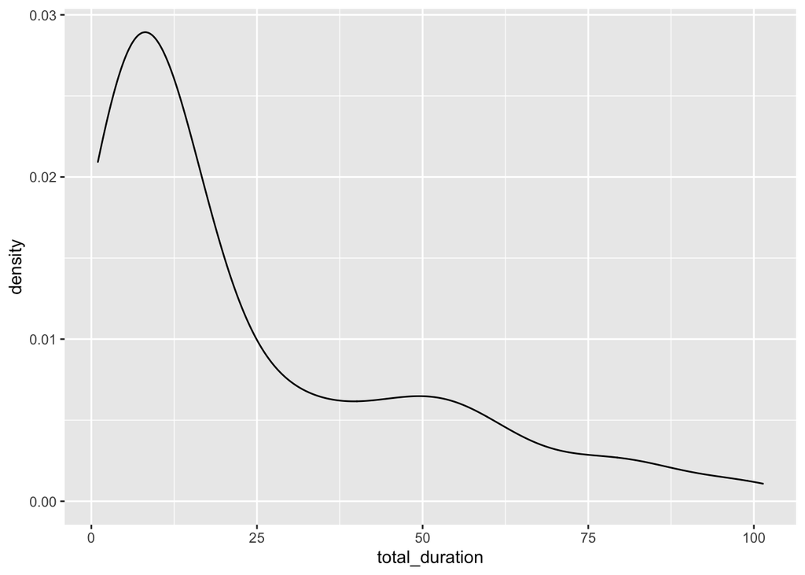

```r
#total duration variable plot
ggplot(politeness, aes(total_duration))+geom_density()
```

```r
# additional information
ls.str(politeness) # general information
```

```
## attitude :  Factor w/ 2 levels "inf","pol": 2 1 2 1 2 1 2 1 2 1 ...
## f0mn :  num [1:224] 215 211 285 266 211 ...
## gender :  Factor w/ 2 levels "F","M": 1 1 1 1 1 1 1 1 1 1 ...
## hiss_count :  int [1:224] 2 0 0 0 0 0 1 0 1 0 ...
## scenario :  Factor w/ 7 levels "1","2","3","4",..: 1 1 2 2 3 3 4 4 5 5 ...
## subject :  Factor w/ 16 levels "F1","F2","F3",..: 1 1 1 1 1 1 1 1 1 1 ...
## total_duration :  num [1:224] 18.39 13.55 5.22 4.25 6.79 ...
```